# Risk Factor Analysis

## Outcome Variable

**Outcome Variable:** haz

## Predictor Variables

**Intervention Variable:** impsan

**Adjustment Set:**

- arm
- sex
- W_mage
- meducyrs
- feducyrs
- hhwealth_quart
- hfoodsec
- W_mhtcm
- W_mwtkg
- W_mbmi
- W_nrooms
- W_nchldlt5
- W_parity
- impfloor
- safeh20
- delta_W_mage
- delta_meducyrs
- delta_feducyrs
- delta_hhwealth_quart
- delta_hfoodsec
- delta_W_mhtcm
- delta_W_mwtkg
- delta_W_mbmi
- delta_W_nrooms
- delta_W_nchldlt5
- delta_W_parity
- delta_impfloor
- delta_safeh20

## Stratifying Variables

The analysis was stratified on these variable(s):

- agecat
- studyid
- country

## Data Summary

| agecat | studyid | country | impsan | n_cell | n |
| --- | --- | --- | --- | --- | --- |
| Birth | COHORTS | GUATEMALA | 1 | 45 | 491 |
| Birth | COHORTS | GUATEMALA | 0 | 446 | 491 |
| Birth | COHORTS | INDIA | 1 | 1767 | 4776 |
| Birth | COHORTS | INDIA | 0 | 3009 | 4776 |
| Birth | COHORTS | PHILIPPINES | 1 | 178 | 1191 |
| Birth | COHORTS | PHILIPPINES | 0 | 1013 | 1191 |
| Birth | CONTENT | PERU | 1 | 1 | 2 |
| Birth | CONTENT | PERU | 0 | 1 | 2 |
| Birth | JiVitA-3 | BANGLADESH | 1 | 15220 | 22431 |
| Birth | JiVitA-3 | BANGLADESH | 0 | 7211 | 22431 |
| Birth | JiVitA-4 | BANGLADESH | 1 | 2181 | 2820 |
| Birth | JiVitA-4 | BANGLADESH | 0 | 639 | 2820 |
| Birth | MAL-ED | BANGLADESH | 1 | 179 | 213 |
| Birth | MAL-ED | BANGLADESH | 0 | 34 | 213 |
| Birth | MAL-ED | BRAZIL | 1 | 59 | 60 |
| Birth | MAL-ED | BRAZIL | 0 | 1 | 60 |
| Birth | MAL-ED | INDIA | 1 | 15 | 40 |
| Birth | MAL-ED | INDIA | 0 | 25 | 40 |
| Birth | MAL-ED | NEPAL | 1 | 25 | 26 |
| Birth | MAL-ED | NEPAL | 0 | 1 | 26 |
| Birth | MAL-ED | PERU | 1 | 52 | 208 |
| Birth | MAL-ED | PERU | 0 | 156 | 208 |
| Birth | MAL-ED | SOUTH AFRICA | 1 | 0 | 95 |
| Birth | MAL-ED | SOUTH AFRICA | 0 | 95 | 95 |
| Birth | MAL-ED | TANZANIA, UNITED REPUBLIC OF | 1 | 0 | 118 |
| Birth | MAL-ED | TANZANIA, UNITED REPUBLIC OF | 0 | 118 | 118 |
| Birth | NIH-Birth | BANGLADESH | 1 | 231 | 608 |
| Birth | NIH-Birth | BANGLADESH | 0 | 377 | 608 |
| Birth | NIH-Crypto | BANGLADESH | 1 | 632 | 721 |
| Birth | NIH-Crypto | BANGLADESH | 0 | 89 | 721 |

[output cut: 70 more lines]

The following strata were considered:

- agecat: 24 months, studyid: COHORTS, country: GUATEMALA
- agecat: 24 months, studyid: COHORTS, country: INDIA
- agecat: 24 months, studyid: COHORTS, country: PHILIPPINES
- agecat: 24 months, studyid: CONTENT, country: PERU
- agecat: 24 months, studyid: JiVitA-3, country: BANGLADESH
- agecat: 24 months, studyid: JiVitA-4, country: BANGLADESH
- agecat: 24 months, studyid: LCNI-5, country: MALAWI
- agecat: 24 months, studyid: MAL-ED, country: BANGLADESH
- agecat: 24 months, studyid: MAL-ED, country: BRAZIL
- agecat: 24 months, studyid: MAL-ED, country: INDIA
- agecat: 24 months, studyid: MAL-ED, country: NEPAL
- agecat: 24 months, studyid: MAL-ED, country: PERU
- agecat: 24 months, studyid: MAL-ED, country: SOUTH AFRICA
- agecat: 24 months, studyid: MAL-ED, country: TANZANIA, UNITED REPUBLIC OF
- agecat: 24 months, studyid: NIH-Birth, country: BANGLADESH
- agecat: 24 months, studyid: NIH-Crypto, country: BANGLADESH
- agecat: 24 months, studyid: PROVIDE, country: BANGLADESH
- agecat: 6 months, studyid: COHORTS, country: GUATEMALA
- agecat: 6 months, studyid: COHORTS, country: INDIA
- agecat: 6 months, studyid: COHORTS, country: PHILIPPINES
- agecat: 6 months, studyid: CONTENT, country: PERU
- agecat: 6 months, studyid: JiVitA-3, country: BANGLADESH
- agecat: 6 months, studyid: JiVitA-4, country: BANGLADESH
- agecat: 6 months, studyid: LCNI-5, country: MALAWI
- agecat: 6 months, studyid: MAL-ED, country: BANGLADESH
- agecat: 6 months, studyid: MAL-ED, country: BRAZIL
- agecat: 6 months, studyid: MAL-ED, country: INDIA
- agecat: 6 months, studyid: MAL-ED, country: NEPAL
- agecat: 6 months, studyid: MAL-ED, country: PERU
- agecat: 6 months, studyid: MAL-ED, country: SOUTH AFRICA
- agecat: 6 months, studyid: MAL-ED, country: TANZANIA, UNITED REPUBLIC OF
- agecat: 6 months, studyid: NIH-Birth, country: BANGLADESH
- agecat: 6 months, studyid: NIH-Crypto, country: BANGLADESH
- agecat: 6 months, studyid: PROVIDE, country: BANGLADESH
- agecat: Birth, studyid: COHORTS, country: GUATEMALA
- agecat: Birth, studyid: COHORTS, country: INDIA
- agecat: Birth, studyid: COHORTS, country: PHILIPPINES
- agecat: Birth, studyid: CONTENT, country: PERU
- agecat: Birth, studyid: JiVitA-3, country: BANGLADESH
- agecat: Birth, studyid: JiVitA-4, country: BANGLADESH
- agecat: Birth, studyid: MAL-ED, country: BANGLADESH
- agecat: Birth, studyid: MAL-ED, country: BRAZIL
- agecat: Birth, studyid: MAL-ED, country: INDIA
- agecat: Birth, studyid: MAL-ED, country: NEPAL
- agecat: Birth, studyid: MAL-ED, country: PERU
- agecat: Birth, studyid: MAL-ED, country: SOUTH AFRICA
- agecat: Birth, studyid: MAL-ED, country: TANZANIA, UNITED REPUBLIC OF
- agecat: Birth, studyid: NIH-Birth, country: BANGLADESH
- agecat: Birth, studyid: NIH-Crypto, country: BANGLADESH
- agecat: Birth, studyid: PROVIDE, country: BANGLADESH

### Dropped Strata

Some strata were dropped due to rare outcomes:

- agecat: Birth, studyid: CONTENT, country: PERU
- agecat: Birth, studyid: MAL-ED, country: BRAZIL
- agecat: Birth, studyid: MAL-ED, country: NEPAL
- agecat: Birth, studyid: MAL-ED, country: SOUTH AFRICA
- agecat: Birth, studyid: MAL-ED, country: TANZANIA, UNITED REPUBLIC OF
- agecat: Birth, studyid: PROVIDE, country: BANGLADESH
- agecat: 6 months, studyid: LCNI-5, country: MALAWI
- agecat: 6 months, studyid: MAL-ED, country: BRAZIL
- agecat: 6 months, studyid: MAL-ED, country: NEPAL
- agecat: 6 months, studyid: MAL-ED, country: SOUTH AFRICA
- agecat: 6 months, studyid: MAL-ED, country: TANZANIA, UNITED REPUBLIC OF
- agecat: 6 months, studyid: PROVIDE, country: BANGLADESH
- agecat: 24 months, studyid: LCNI-5, country: MALAWI
- agecat: 24 months, studyid: MAL-ED, country: BRAZIL
- agecat: 24 months, studyid: MAL-ED, country: NEPAL
- agecat: 24 months, studyid: MAL-ED, country: SOUTH AFRICA
- agecat: 24 months, studyid: MAL-ED, country: TANZANIA, UNITED REPUBLIC OF
- agecat: 24 months, studyid: PROVIDE, country: BANGLADESH

## Methods Detail

We’re interested in the causal parameters $E[Y_a]$ for all values of $a \in \mathcal{A}$. These parameters represent the mean outcome if, possibly contrary to fact, we intervened to set all units to have $A=a$. Under the randomization and positivity assumptions, these are identified by the statistical parameters $\psi_a=E_W[E_{Y|A,W}(Y|A=a,W)]$. In addition, we’re interested in the mean of $Y$, $E[Y]$ under no intervention (the observed mean). We will estimate these parameters by using SuperLearner to fit the relevant likelihood factors – $E_{Y|A,W}(Y|A=a,W)$ and $p(A=a|W)$, and then updating our likelihood fit using a joint TMLE.

For unadjusted analyses ($W=\{\}$), initial likelihoods were estimated using Lrnr_glm to estimate the simple $E(Y|A)$ and Lrnr_mean to estimate $p(A)$. For adjusted analyses, a small library containing Lrnr_glmnet, Lrnr_xgboost, and Lrnr_mean was used.

Having estimated these parameters, we will then use the delta method to estimate relative risks and attributable risks relative to a prespecified baseline level of $A$.

# Results Detail

## Results Plots

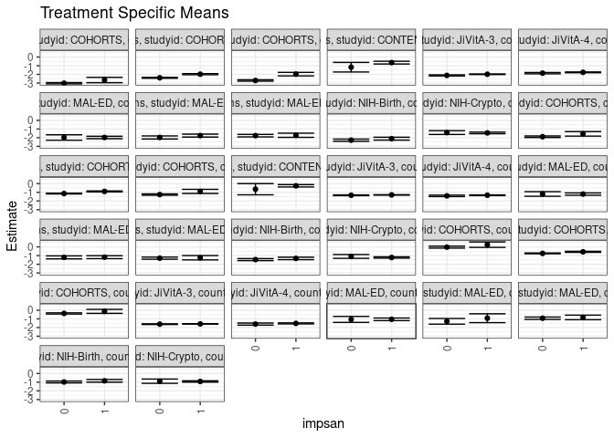

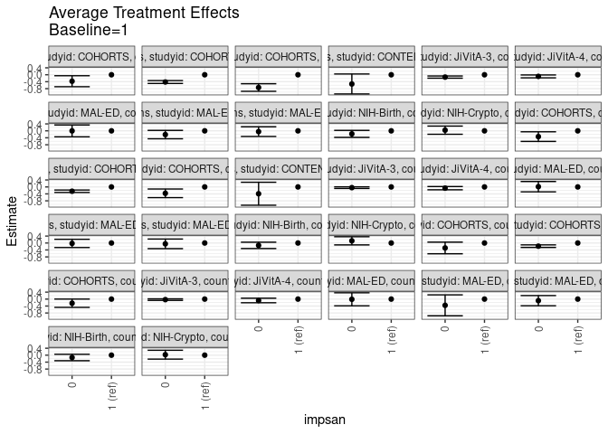

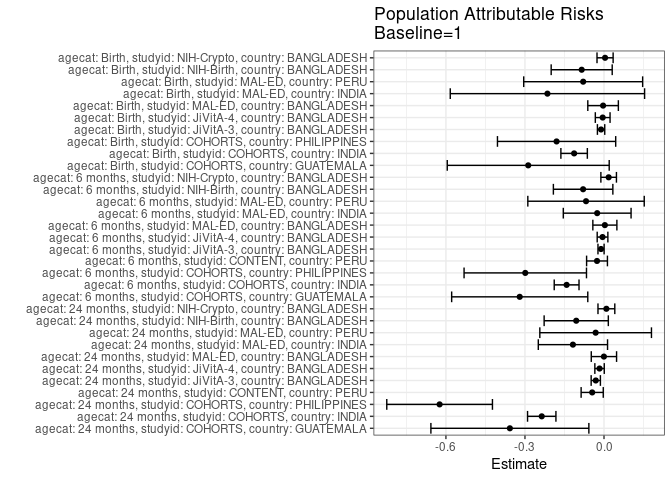

## Results Table

### Parameter: TSM

| agecat | studyid | country | intervention_level | baseline_level | estimate | ci_lower | ci_upper |
| --- | --- | --- | --- | --- | --- | --- | --- |
| Birth | COHORTS | GUATEMALA | 1 | NA | 0.2600548 | -0.0542507 | 0.5743603 |
| Birth | COHORTS | GUATEMALA | 0 | NA | -0.0242294 | -0.1390558 | 0.0905970 |
| Birth | COHORTS | INDIA | 1 | NA | -0.5642788 | -0.6245426 | -0.5040150 |
| Birth | COHORTS | INDIA | 0 | NA | -0.7459623 | -0.7884467 | -0.7034779 |
| Birth | COHORTS | PHILIPPINES | 1 | NA | -0.1337440 | -0.3628647 | 0.0953767 |
| Birth | COHORTS | PHILIPPINES | 0 | NA | -0.3717944 | -0.4418612 | -0.3017276 |
| Birth | JiVitA-3 | BANGLADESH | 1 | NA | -1.5787292 | -1.6021728 | -1.5552856 |
| Birth | JiVitA-3 | BANGLADESH | 0 | NA | -1.6095000 | -1.6495024 | -1.5694976 |
| Birth | JiVitA-4 | BANGLADESH | 1 | NA | -1.5186175 | -1.5758534 | -1.4613816 |
| Birth | JiVitA-4 | BANGLADESH | 0 | NA | -1.5986410 | -1.7184923 | -1.4787896 |
| Birth | MAL-ED | BANGLADESH | 1 | NA | -1.0495547 | -1.1994044 | -0.8997051 |
| Birth | MAL-ED | BANGLADESH | 0 | NA | -1.0614710 | -1.4041800 | -0.7187621 |
| Birth | MAL-ED | INDIA | 1 | NA | -0.9227733 | -1.4330942 | -0.4124524 |
| Birth | MAL-ED | INDIA | 0 | NA | -1.2815145 | -1.6083536 | -0.9546755 |
| Birth | MAL-ED | PERU | 1 | NA | -0.8341461 | -1.0963390 | -0.5719532 |
| Birth | MAL-ED | PERU | 0 | NA | -0.9247904 | -1.0601504 | -0.7894303 |
| Birth | NIH-Birth | BANGLADESH | 1 | NA | -0.8463348 | -0.9982333 | -0.6944364 |
| Birth | NIH-Birth | BANGLADESH | 0 | NA | -0.9797391 | -1.0875013 | -0.8719769 |
| Birth | NIH-Crypto | BANGLADESH | 1 | NA | -0.9171520 | -0.9918554 | -0.8424486 |
| Birth | NIH-Crypto | BANGLADESH | 0 | NA | -0.8888976 | -1.1332983 | -0.6444970 |
| 6 months | COHORTS | GUATEMALA | 1 | NA | -1.5590298 | -1.8204609 | -1.2975987 |
| 6 months | COHORTS | GUATEMALA | 0 | NA | -1.8903896 | -1.9790729 | -1.8017063 |
| 6 months | COHORTS | INDIA | 1 | NA | -0.8995534 | -0.9558870 | -0.8432198 |
| 6 months | COHORTS | INDIA | 0 | NA | -1.1468504 | -1.1891379 | -1.1045629 |
| 6 months | COHORTS | PHILIPPINES | 1 | NA | -0.8955039 | -1.1322803 | -0.6587275 |
| 6 months | COHORTS | PHILIPPINES | 0 | NA | -1.2629391 | -1.3373717 | -1.1885064 |
| 6 months | CONTENT | PERU | 1 | NA | -0.2519948 | -0.3866442 | -0.1173454 |
| 6 months | CONTENT | PERU | 0 | NA | -0.6440652 | -1.2910064 | 0.0028760 |
| 6 months | JiVitA-3 | BANGLADESH | 1 | NA | -1.3022210 | -1.3280589 | -1.2763831 |
| 6 months | JiVitA-3 | BANGLADESH | 0 | NA | -1.3431627 | -1.3899875 | -1.2963379 |
| 6 months | JiVitA-4 | BANGLADESH | 1 | NA | -1.3384565 | -1.3803632 | -1.2965499 |
| 6 months | JiVitA-4 | BANGLADESH | 0 | NA | -1.4082583 | -1.4915353 | -1.3249813 |
| 6 months | MAL-ED | BANGLADESH | 1 | NA | -1.2059424 | -1.3384234 | -1.0734614 |
| 6 months | MAL-ED | BANGLADESH | 0 | NA | -1.1907599 | -1.4575384 | -0.9239815 |
| 6 months | MAL-ED | INDIA | 1 | NA | -1.1828452 | -1.3505769 | -1.0151135 |
| 6 months | MAL-ED | INDIA | 0 | NA | -1.2059328 | -1.3760307 | -1.0358349 |
| 6 months | MAL-ED | PERU | 1 | NA | -1.2514178 | -1.5000928 | -1.0027429 |
| 6 months | MAL-ED | PERU | 0 | NA | -1.2992222 | -1.4209154 | -1.1775290 |
| 6 months | NIH-Birth | BANGLADESH | 1 | NA | -1.3281106 | -1.4699887 | -1.1862325 |
| 6 months | NIH-Birth | BANGLADESH | 0 | NA | -1.4637098 | -1.5804677 | -1.3469520 |
| 6 months | NIH-Crypto | BANGLADESH | 1 | NA | -1.2207783 | -1.2968155 | -1.1447411 |
| 6 months | NIH-Crypto | BANGLADESH | 0 | NA | -1.0951240 | -1.3179128 | -0.8723351 |
| 24 months | COHORTS | GUATEMALA | 1 | NA | -2.6478464 | -2.9545136 | -2.3411792 |
| 24 months | COHORTS | GUATEMALA | 0 | NA | -3.0196223 | -3.0939499 | -2.9452947 |
| 24 months | COHORTS | INDIA | 1 | NA | -1.9763386 | -2.0412360 | -1.9114412 |
| 24 months | COHORTS | INDIA | 0 | NA | -2.3933025 | -2.4467220 | -2.3398831 |
| 24 months | COHORTS | PHILIPPINES | 1 | NA | -1.9698148 | -2.1709377 | -1.7686919 |
| 24 months | COHORTS | PHILIPPINES | 0 | NA | -2.7036940 | -2.7854728 | -2.6219151 |
| 24 months | CONTENT | PERU | 1 | NA | -0.6420430 | -0.8017458 | -0.4823402 |
| 24 months | CONTENT | PERU | 0 | NA | -1.1727195 | -1.7256672 | -0.6197718 |
| 24 months | JiVitA-3 | BANGLADESH | 1 | NA | -1.9824911 | -2.0155324 | -1.9494498 |
| 24 months | JiVitA-3 | BANGLADESH | 0 | NA | -2.1163440 | -2.1761119 | -2.0565761 |
| 24 months | JiVitA-4 | BANGLADESH | 1 | NA | -1.7634972 | -1.8051268 | -1.7218676 |
| 24 months | JiVitA-4 | BANGLADESH | 0 | NA | -1.8574254 | -1.9325043 | -1.7823465 |
| 24 months | MAL-ED | BANGLADESH | 1 | NA | -1.9780852 | -2.1178302 | -1.8383401 |
| 24 months | MAL-ED | BANGLADESH | 0 | NA | -1.9798569 | -2.2909902 | -1.6687236 |
| 24 months | MAL-ED | INDIA | 1 | NA | -1.7599952 | -1.9290822 | -1.5909083 |
| 24 months | MAL-ED | INDIA | 0 | NA | -1.9749902 | -2.1527670 | -1.7972133 |
| 24 months | MAL-ED | PERU | 1 | NA | -1.7217919 | -1.9611932 | -1.4823906 |
| 24 months | MAL-ED | PERU | 0 | NA | -1.7650050 | -1.9083625 | -1.6216474 |
| 24 months | NIH-Birth | BANGLADESH | 1 | NA | -2.1136400 | -2.2782248 | -1.9490553 |
| 24 months | NIH-Birth | BANGLADESH | 0 | NA | -2.2877917 | -2.4125958 | -2.1629876 |
| 24 months | NIH-Crypto | BANGLADESH | 1 | NA | -1.4507729 | -1.5426591 | -1.3588867 |
| 24 months | NIH-Crypto | BANGLADESH | 0 | NA | -1.4110307 | -1.6283887 | -1.1936726 |

### Parameter: E(Y)

| agecat | studyid | country | intervention_level | baseline_level | estimate | ci_lower | ci_upper |
| --- | --- | --- | --- | --- | --- | --- | --- |
| Birth | COHORTS | GUATEMALA | NA | NA | -0.0275356 | -0.1359303 | 0.0808590 |
| Birth | COHORTS | INDIA | NA | NA | -0.6777115 | -0.7106054 | -0.6448175 |
| Birth | COHORTS | PHILIPPINES | NA | NA | -0.3137364 | -0.3764483 | -0.2510244 |
| Birth | JiVitA-3 | BANGLADESH | NA | NA | -1.5898288 | -1.6090823 | -1.5705753 |
| Birth | JiVitA-4 | BANGLADESH | NA | NA | -1.5236135 | -1.5727559 | -1.4744711 |
| Birth | MAL-ED | BANGLADESH | NA | NA | -1.0530516 | -1.1896058 | -0.9164975 |
| Birth | MAL-ED | INDIA | NA | NA | -1.1375000 | -1.4325178 | -0.8424822 |
| Birth | MAL-ED | PERU | NA | NA | -0.9131731 | -1.0331160 | -0.7932301 |
| Birth | NIH-Birth | BANGLADESH | NA | NA | -0.9310197 | -1.0197391 | -0.8423003 |
| Birth | NIH-Crypto | BANGLADESH | NA | NA | -0.9131068 | -0.9851939 | -0.8410197 |
| 6 months | COHORTS | GUATEMALA | NA | NA | -1.8789210 | -1.9609921 | -1.7968498 |
| 6 months | COHORTS | INDIA | NA | NA | -1.0414424 | -1.0741113 | -1.0087734 |
| 6 months | COHORTS | PHILIPPINES | NA | NA | -1.1942936 | -1.2608624 | -1.1277248 |
| 6 months | CONTENT | PERU | NA | NA | -0.2785256 | -0.4098735 | -0.1471776 |
| 6 months | JiVitA-3 | BANGLADESH | NA | NA | -1.3134804 | -1.3366079 | -1.2903528 |
| 6 months | JiVitA-4 | BANGLADESH | NA | NA | -1.3440477 | -1.3813060 | -1.3067894 |
| 6 months | MAL-ED | BANGLADESH | NA | NA | -1.2026806 | -1.3203025 | -1.0850586 |
| 6 months | MAL-ED | INDIA | NA | NA | -1.2087268 | -1.3282418 | -1.0892117 |
| 6 months | MAL-ED | PERU | NA | NA | -1.3196229 | -1.4293681 | -1.2098778 |
| 6 months | NIH-Birth | BANGLADESH | NA | NA | -1.4073821 | -1.4960598 | -1.3187043 |
| 6 months | NIH-Crypto | BANGLADESH | NA | NA | -1.2031037 | -1.2749632 | -1.1312442 |
| 24 months | COHORTS | GUATEMALA | NA | NA | -3.0050840 | -3.0758338 | -2.9343342 |
| 24 months | COHORTS | INDIA | NA | NA | -2.2126633 | -2.2518337 | -2.1734929 |
| 24 months | COHORTS | PHILIPPINES | NA | NA | -2.5937576 | -2.6629996 | -2.5245156 |
| 24 months | CONTENT | PERU | NA | NA | -0.6868598 | -0.8388476 | -0.5348719 |
| 24 months | JiVitA-3 | BANGLADESH | NA | NA | -2.0136975 | -2.0413718 | -1.9860232 |
| 24 months | JiVitA-4 | BANGLADESH | NA | NA | -1.7803708 | -1.8158650 | -1.7448765 |
| 24 months | MAL-ED | BANGLADESH | NA | NA | -1.9783962 | -2.1050210 | -1.8517715 |
| 24 months | MAL-ED | INDIA | NA | NA | -1.8779556 | -2.0033207 | -1.7525904 |
| 24 months | MAL-ED | PERU | NA | NA | -1.7535204 | -1.8760973 | -1.6309435 |
| 24 months | NIH-Birth | BANGLADESH | NA | NA | -2.2190579 | -2.3217459 | -2.1163699 |
| 24 months | NIH-Crypto | BANGLADESH | NA | NA | -1.4417097 | -1.5263855 | -1.3570340 |

### Parameter: ATE

| agecat | studyid | country | intervention_level | baseline_level | estimate | ci_lower | ci_upper |
| --- | --- | --- | --- | --- | --- | --- | --- |
| Birth | COHORTS | GUATEMALA | 1 | 1 | 0.0000000 | 0.0000000 | 0.0000000 |
| Birth | COHORTS | GUATEMALA | 0 | 1 | -0.2842842 | -0.6190062 | 0.0504377 |
| Birth | COHORTS | INDIA | 1 | 1 | 0.0000000 | 0.0000000 | 0.0000000 |
| Birth | COHORTS | INDIA | 0 | 1 | -0.1816835 | -0.2550238 | -0.1083431 |
| Birth | COHORTS | PHILIPPINES | 1 | 1 | 0.0000000 | 0.0000000 | 0.0000000 |
| Birth | COHORTS | PHILIPPINES | 0 | 1 | -0.2380504 | -0.4774992 | 0.0013984 |
| Birth | JiVitA-3 | BANGLADESH | 1 | 1 | 0.0000000 | 0.0000000 | 0.0000000 |
| Birth | JiVitA-3 | BANGLADESH | 0 | 1 | -0.0307708 | -0.0747612 | 0.0132196 |
| Birth | JiVitA-4 | BANGLADESH | 1 | 1 | 0.0000000 | 0.0000000 | 0.0000000 |
| Birth | JiVitA-4 | BANGLADESH | 0 | 1 | -0.0800235 | -0.2111427 | 0.0510958 |
| Birth | MAL-ED | BANGLADESH | 1 | 1 | 0.0000000 | 0.0000000 | 0.0000000 |
| Birth | MAL-ED | BANGLADESH | 0 | 1 | -0.0119163 | -0.3865604 | 0.3627278 |
| Birth | MAL-ED | INDIA | 1 | 1 | 0.0000000 | 0.0000000 | 0.0000000 |
| Birth | MAL-ED | INDIA | 0 | 1 | -0.3587413 | -0.9618128 | 0.2443303 |
| Birth | MAL-ED | PERU | 1 | 1 | 0.0000000 | 0.0000000 | 0.0000000 |
| Birth | MAL-ED | PERU | 0 | 1 | -0.0906443 | -0.3849647 | 0.2036761 |
| Birth | NIH-Birth | BANGLADESH | 1 | 1 | 0.0000000 | 0.0000000 | 0.0000000 |
| Birth | NIH-Birth | BANGLADESH | 0 | 1 | -0.1334043 | -0.3185903 | 0.0517818 |
| Birth | NIH-Crypto | BANGLADESH | 1 | 1 | 0.0000000 | 0.0000000 | 0.0000000 |
| Birth | NIH-Crypto | BANGLADESH | 0 | 1 | 0.0282544 | -0.2268875 | 0.2833962 |
| 6 months | COHORTS | GUATEMALA | 1 | 1 | 0.0000000 | 0.0000000 | 0.0000000 |
| 6 months | COHORTS | GUATEMALA | 0 | 1 | -0.3313598 | -0.6076724 | -0.0550472 |
| 6 months | COHORTS | INDIA | 1 | 1 | 0.0000000 | 0.0000000 | 0.0000000 |
| 6 months | COHORTS | INDIA | 0 | 1 | -0.2472970 | -0.3167046 | -0.1778895 |
| 6 months | COHORTS | PHILIPPINES | 1 | 1 | 0.0000000 | 0.0000000 | 0.0000000 |
| 6 months | COHORTS | PHILIPPINES | 0 | 1 | -0.3674351 | -0.6160619 | -0.1188084 |
| 6 months | CONTENT | PERU | 1 | 1 | 0.0000000 | 0.0000000 | 0.0000000 |
| 6 months | CONTENT | PERU | 0 | 1 | -0.3920704 | -1.0530538 | 0.2689129 |
| 6 months | JiVitA-3 | BANGLADESH | 1 | 1 | 0.0000000 | 0.0000000 | 0.0000000 |
| 6 months | JiVitA-3 | BANGLADESH | 0 | 1 | -0.0409417 | -0.0878215 | 0.0059381 |
| 6 months | JiVitA-4 | BANGLADESH | 1 | 1 | 0.0000000 | 0.0000000 | 0.0000000 |
| 6 months | JiVitA-4 | BANGLADESH | 0 | 1 | -0.0698017 | -0.1632772 | 0.0236738 |
| 6 months | MAL-ED | BANGLADESH | 1 | 1 | 0.0000000 | 0.0000000 | 0.0000000 |
| 6 months | MAL-ED | BANGLADESH | 0 | 1 | 0.0151825 | -0.2828851 | 0.3132500 |
| 6 months | MAL-ED | INDIA | 1 | 1 | 0.0000000 | 0.0000000 | 0.0000000 |
| 6 months | MAL-ED | INDIA | 0 | 1 | -0.0230876 | -0.2611941 | 0.2150188 |
| 6 months | MAL-ED | PERU | 1 | 1 | 0.0000000 | 0.0000000 | 0.0000000 |
| 6 months | MAL-ED | PERU | 0 | 1 | -0.0478044 | -0.3244771 | 0.2288683 |
| 6 months | NIH-Birth | BANGLADESH | 1 | 1 | 0.0000000 | 0.0000000 | 0.0000000 |
| 6 months | NIH-Birth | BANGLADESH | 0 | 1 | -0.1355993 | -0.3177968 | 0.0465983 |
| 6 months | NIH-Crypto | BANGLADESH | 1 | 1 | 0.0000000 | 0.0000000 | 0.0000000 |
| 6 months | NIH-Crypto | BANGLADESH | 0 | 1 | 0.1256544 | -0.1098589 | 0.3611676 |
| 24 months | COHORTS | GUATEMALA | 1 | 1 | 0.0000000 | 0.0000000 | 0.0000000 |
| 24 months | COHORTS | GUATEMALA | 0 | 1 | -0.3717759 | -0.6874262 | -0.0561256 |
| 24 months | COHORTS | INDIA | 1 | 1 | 0.0000000 | 0.0000000 | 0.0000000 |
| 24 months | COHORTS | INDIA | 0 | 1 | -0.4169640 | -0.5011450 | -0.3327830 |
| 24 months | COHORTS | PHILIPPINES | 1 | 1 | 0.0000000 | 0.0000000 | 0.0000000 |
| 24 months | COHORTS | PHILIPPINES | 0 | 1 | -0.7338792 | -0.9519791 | -0.5157793 |
| 24 months | CONTENT | PERU | 1 | 1 | 0.0000000 | 0.0000000 | 0.0000000 |
| 24 months | CONTENT | PERU | 0 | 1 | -0.5306765 | -1.1052782 | 0.0439252 |
| 24 months | JiVitA-3 | BANGLADESH | 1 | 1 | 0.0000000 | 0.0000000 | 0.0000000 |
| 24 months | JiVitA-3 | BANGLADESH | 0 | 1 | -0.1338529 | -0.1967749 | -0.0709310 |
| 24 months | JiVitA-4 | BANGLADESH | 1 | 1 | 0.0000000 | 0.0000000 | 0.0000000 |
| 24 months | JiVitA-4 | BANGLADESH | 0 | 1 | -0.0939282 | -0.1770500 | -0.0108064 |
| 24 months | MAL-ED | BANGLADESH | 1 | 1 | 0.0000000 | 0.0000000 | 0.0000000 |
| 24 months | MAL-ED | BANGLADESH | 0 | 1 | -0.0017717 | -0.3431207 | 0.3395773 |
| 24 months | MAL-ED | INDIA | 1 | 1 | 0.0000000 | 0.0000000 | 0.0000000 |
| 24 months | MAL-ED | INDIA | 0 | 1 | -0.2149949 | -0.4571161 | 0.0271262 |
| 24 months | MAL-ED | PERU | 1 | 1 | 0.0000000 | 0.0000000 | 0.0000000 |
| 24 months | MAL-ED | PERU | 0 | 1 | -0.0432131 | -0.3211393 | 0.2347131 |
| 24 months | NIH-Birth | BANGLADESH | 1 | 1 | 0.0000000 | 0.0000000 | 0.0000000 |
| 24 months | NIH-Birth | BANGLADESH | 0 | 1 | -0.1741516 | -0.3754659 | 0.0271626 |
| 24 months | NIH-Crypto | BANGLADESH | 1 | 1 | 0.0000000 | 0.0000000 | 0.0000000 |
| 24 months | NIH-Crypto | BANGLADESH | 0 | 1 | 0.0397422 | -0.1958999 | 0.2753843 |

### Parameter: PAR

| agecat | studyid | country | intervention_level | baseline_level | estimate | ci_lower | ci_upper |
| --- | --- | --- | --- | --- | --- | --- | --- |
| Birth | COHORTS | GUATEMALA | 1 | NA | -0.2875905 | -0.5949378 | 0.0197569 |
| Birth | COHORTS | INDIA | 1 | NA | -0.1134326 | -0.1636450 | -0.0632202 |
| Birth | COHORTS | PHILIPPINES | 1 | NA | -0.1799924 | -0.4043644 | 0.0443797 |
| Birth | JiVitA-3 | BANGLADESH | 1 | NA | -0.0110996 | -0.0250050 | 0.0028058 |
| Birth | JiVitA-4 | BANGLADESH | 1 | NA | -0.0049960 | -0.0329505 | 0.0229586 |
| Birth | MAL-ED | BANGLADESH | 1 | NA | -0.0034969 | -0.0614877 | 0.0544939 |
| Birth | MAL-ED | INDIA | 1 | NA | -0.2147267 | -0.5835218 | 0.1540684 |
| Birth | MAL-ED | PERU | 1 | NA | -0.0790270 | -0.3047567 | 0.1467027 |
| Birth | NIH-Birth | BANGLADESH | 1 | NA | -0.0846849 | -0.2004935 | 0.0311237 |
| Birth | NIH-Crypto | BANGLADESH | 1 | NA | 0.0040452 | -0.0265528 | 0.0346432 |
| 6 months | COHORTS | GUATEMALA | 1 | NA | -0.3198912 | -0.5782060 | -0.0615764 |
| 6 months | COHORTS | INDIA | 1 | NA | -0.1418890 | -0.1889407 | -0.0948372 |
| 6 months | COHORTS | PHILIPPINES | 1 | NA | -0.2987897 | -0.5311113 | -0.0664681 |
| 6 months | CONTENT | PERU | 1 | NA | -0.0265308 | -0.0660676 | 0.0130059 |
| 6 months | JiVitA-3 | BANGLADESH | 1 | NA | -0.0112594 | -0.0228852 | 0.0003665 |
| 6 months | JiVitA-4 | BANGLADESH | 1 | NA | -0.0055911 | -0.0258487 | 0.0146665 |
| 6 months | MAL-ED | BANGLADESH | 1 | NA | 0.0032618 | -0.0423575 | 0.0488812 |
| 6 months | MAL-ED | INDIA | 1 | NA | -0.0258816 | -0.1545062 | 0.1027431 |
| 6 months | MAL-ED | PERU | 1 | NA | -0.0682051 | -0.2891379 | 0.1527277 |
| 6 months | NIH-Birth | BANGLADESH | 1 | NA | -0.0792715 | -0.1921452 | 0.0336022 |
| 6 months | NIH-Crypto | BANGLADESH | 1 | NA | 0.0176746 | -0.0118646 | 0.0472139 |
| 24 months | COHORTS | GUATEMALA | 1 | NA | -0.3572376 | -0.6570214 | -0.0574537 |
| 24 months | COHORTS | INDIA | 1 | NA | -0.2363247 | -0.2901819 | -0.1824676 |
| 24 months | COHORTS | PHILIPPINES | 1 | NA | -0.6239428 | -0.8244970 | -0.4233885 |
| 24 months | CONTENT | PERU | 1 | NA | -0.0448167 | -0.0868280 | -0.0028055 |
| 24 months | JiVitA-3 | BANGLADESH | 1 | NA | -0.0312064 | -0.0487566 | -0.0136562 |
| 24 months | JiVitA-4 | BANGLADESH | 1 | NA | -0.0168736 | -0.0347419 | 0.0009948 |
| 24 months | MAL-ED | BANGLADESH | 1 | NA | -0.0003110 | -0.0483065 | 0.0476845 |
| 24 months | MAL-ED | INDIA | 1 | NA | -0.1179603 | -0.2493673 | 0.0134466 |
| 24 months | MAL-ED | PERU | 1 | NA | -0.0317285 | -0.2435795 | 0.1801224 |
| 24 months | NIH-Birth | BANGLADESH | 1 | NA | -0.1054178 | -0.2272227 | 0.0163870 |
| 24 months | NIH-Crypto | BANGLADESH | 1 | NA | 0.0090632 | -0.0228493 | 0.0409756 |